# Modeling field trials using RAP

Bart-Jan van Rossum

2018-10-09

# 1 The RAP Package

The RAP package is developed as an easy to use package for analysing data of plant breeding experiments with plenty of options for plotting and reporting the results of the analyses.

The package has 3 main components:

- Modeling trial data for single trials and extracting results
- Genotype by Environment (GxE) analysis
- QTL analysis

This vignette deals with the modeling part of the package and describes in detail how to prepare data for analysis, perform analysis using different modeling engines and extract the results from the models.

# 2 Data preparation

The first step when modeling field trial data or performing a GxE analysis with the RAP package is creating an object of class `TD`. This object is used by the RAP package for performing most analyses.

## 2.1 Creating a `TD` object

A `TD` object can be created from a `data.frame` with the function `createTD`. This function does a number of things:

- Rename columns to default column names used by the RAP package. For example, the column in the data containing variety/accession/genotype is renamed to `genotype`. Original column names are stored as an attribute of the `TD` object.
- Convert column type to the default column types. For example the column genotype is converted to a factor and rowCoord to a numeric column.
- Split the data into separate data.frames by trial. The output `TD` object is a `list` of `data.frames` where each `data.frame` contains the data for a single trial. If there is only one trial or no column trial is defined the output will be a `list` with only one item.
- Add meta data to the separate `data.frames` in the `TD` object. The meta data consists of location, date of the experiment, longitude, latitude, trial design, plot width and plot length. None of these is strictly neccessary for any analysis but the meta data is used for plotting field layouts, plotting trials on a map and naming plots. Meta data for a single trial can simply be added when creating the `TD` object using the parameters in `createTD`. However if the data consists of multiple trials with different meta data per trial it is more convenient to first create a `TD` object without adding meta data. This will still add a location based on the name of the trial. After creating the `TD` object the meta data can then be extracted using `getMeta`. This function outputs a `data.frame` with the meta data per trial. The content of this `data.frame` can then be modified and added back to the `TD` object using `setMeta`.

After creating a `TD` object data for new trials can be added to it using `addTD`. This function works in exactly the same way as `createTD` except that it adds data to an existing `TD` object instead of creating a new one.  
Dropping one or more trials from a `TD` object can be done using the function `dropTD` specifying the trials to drop in the parameter `trials`.

## 2.2 Example

Field data from an experiment with wheat in Chili described in detail by Lado et al. (2013) will be used as an example throughout this vignette. The experiment was performed in 2 locations in Chili with 2 different drought regimes in 2011 and 2012 for the first location and 1 trial in 2012 for the second location. For 384 genotypes 4 traits were measured in 2011 but in 2012 only grain yield (GY) was measured and the examples will mainly focus on this trait.

For the example first a `TD` object is created for the first location and the data for the second location is then added later on. In practice all this could be done in one go.

```r
data("wheatChl")
wheatTD <- createTD(data = wheatChl[wheatChl$trial != "C_SWS_12", ],
                    genotype = "trt_id", repId = "rep", subBlock = "bl",
                    rowCoord = "row", colCoord = "col")
```

The `TD` object just created is a `list` with 4 items, 1 for each trial (combination of location, drought regime and year) in the original `data.frame`.

## 2.3 Meta data

The meta data will be a `data.frame` with 4 rows, 1 for each item in `wheatTD`.

```r
(wheatMeta <- getMeta(TD = wheatTD))
```

```
#>           trLocation trDate trDesign trLat trLong trPlWidth trPlLength
#> SR_FI_11    SR_FI_11   <NA>       NA    NA     NA        NA         NA
#> SR_FI_12    SR_FI_12   <NA>       NA    NA     NA        NA         NA
#> SR_MWS_11  SR_MWS_11   <NA>       NA    NA     NA        NA         NA
#> SR_MWS_12  SR_MWS_12   <NA>       NA    NA     NA        NA         NA
```

After extracting the meta data it can be modified and then added it back to the original `TD` object.

```r
wheatMeta$trLocation <- "Santa Rosa"
wheatMeta$trDate <- as.Date(rep(c("310811", "310812"), times = 2), "%d%m%y")
wheatMeta$trLat <- -36.32
wheatMeta$trLong <- -71.55
wheatMeta$trPlWidth = 2
wheatMeta$trPlLength = 1
wheatTD <- setMeta(TD = wheatTD, meta = wheatMeta)
```

## 2.4 Add extra data to a `TD` object

To add the data for the final trial to the `TD` object the function `addTD` can be used. Since now 1 new trial is added it makes sense to immediately add the meta data for this trial as well using the appropriate parameters in `addTD`.

```r
wheatTD <- addTD(TD = wheatTD, data = wheatChl[wheatChl$trial == "C_SWS_12", ],
                 genotype = "trt_id", repId = "rep", subBlock = "bl",
                 rowCoord = "row", colCoord = "col", trLocation = "Cauquenes",
                 trDate = as.Date("070912", "%d%m%y"), trLat = -35.58,
                 trLong = -72.17, trPlWidth = 2, trPlLength = 1)
## Inspect the meta data after the extra trial was added.
getMeta(TD = wheatTD)
```

```
#>           trLocation     trDate trDesign  trLat trLong trPlWidth trPlLength
#> SR_FI_11  Santa Rosa 2011-08-31       NA -36.32 -71.55         2          1
#> SR_FI_12  Santa Rosa 2012-08-31       NA -36.32 -71.55         2          1
#> SR_MWS_11 Santa Rosa 2011-08-31       NA -36.32 -71.55         2          1
#> SR_MWS_12 Santa Rosa 2012-08-31       NA -36.32 -71.55         2          1
#> C_SWS_12   Cauquenes 2012-09-07       NA -35.58 -72.17         2          1
```

## 2.5 Summarising a `TD` object

Use the `summary` function to get an idea of the content of the data in the `TD` object. Multiple traits may be summarised at once but for clarity here a summary is only made for GY.

```r
summary(wheatTD, trial = "SR_FI_11", traits = "GY")
```

```
#>
#> Summary statistics for GY in SR_FI_11
#>
#>     Number of observations  794
#>   Number of missing values  6
#>                       Mean  8015.6
#>                     Median  8021
#>                        Min  2239.5
#>                        Max  12992
#>             Lower quartile  6728.5
#>             Upper quartile  9321.75
#>                   Variance  3080361.436
```

Using the default options 9 summary statistics are printed, but many more are available. These can be accessed using the parameter `what` in the `summary` function. For a full list of available statistics use `help(summary.TD)`. It is also possible to output all statistics using `what = "all"`.

## 2.6 Plotting a `TD` object

The default plot creates plots for the layout of all trials in the `TD` object. This can be restricted to selected trials using the `trials` parameter. The width and length of the plot are derived from the trPlWidth and trPlLength in the meta data if these are available.

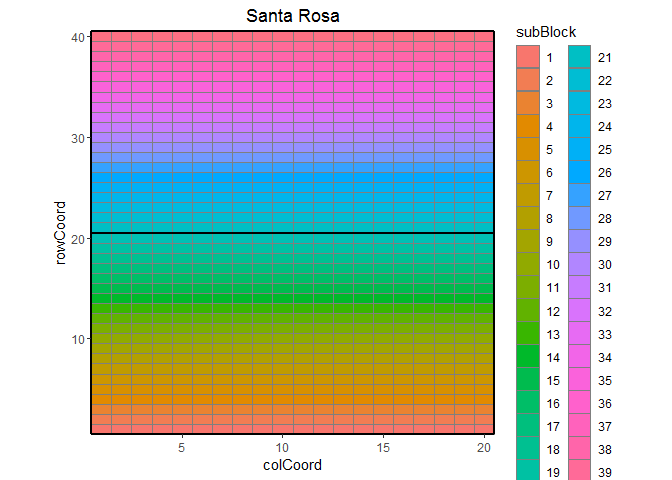

```r
plot(wheatTD, trials = "SR_FI_11")
```

A second type of plot displays the trial locations on a map. This plot is made based on trLat and trLong in the meta data. If not available the corresponding location is not plotted.

```r
#plot(wheatTD, plotType = "map")
```

# 3 Modeling

After creating a `TD` object the next step usually is fitting a model on the trial data. This is done using the function `STRunModel`. Depending on the design of the trial several different models can be fitted. The design can be given as a parameter in the function or included in the meta data of the `TD` object. In the former case the same model will be fitted for all trials, in the latter different models can be fitted for different trials depending on the design. If both are available the function parameter will always be leading.

The output of `STRunModel` is an object of class `SSA` (Single Site Analysis), a `list` of fitted models with 1 item for each trial the model was fitted for.

## 3.1 Model types

`STRunModel` uses 3 different engines for fitting the models, namely SpATS (Rodríguez-Álvarez et al. 2017), lme4 (Bates et al. 2015) and asreml (Gilmour et al. 2009). For models with rowcol or res.rowcol design SpATS is the default engine, for the other models lme4. This can always be overruled by specifying the function parameter `engine`.

At the moment of writing models can be fitted for 5 different trial designs. These are listed in the following table with their respective specifications.

| design | model fitted |
| --- | --- |
| ibd | trait = genotype + *subBlock* + $\epsilon$ |
| res.ibd | trait = genotype + **repId** + **repId:subBlock** + $\epsilon$ |
| rcbd | trait = genotype + **repId** + $\epsilon$ |
| rowcol | trait = genotype + *rowId* + *colId* + $\epsilon$ |
| res.rowcol | trait = genotype + **repId** + *repId:rowId* + *repId:colId* + $\epsilon$ |

Using the `TD` object wheatTD from the previous section a model for the trial SR_FI_11 and trait GY can now be fitted on the data as follows. For the design of the trial a residual row column design is assumed. Since `engine` is not supplied as a parameter SpATS is used for fitting the model.

```r
modWheatSp <- STRunModel(TD = wheatTD, trials = "SR_FI_11", traits = "GY",
                         design = "res.rowcol")
```

Note that by not supplying the `what` argument to the function two models are fitted, one with genotype as a fixed effect and one with genotype as a random effect. The results of both these models are stored in the `SSA` object `modWheatSp`. This is very useful for extracting different results from the model later on. A trade off is that fitting 2 models takes more time than fitting only 1 so when fitting models on large datasets it is sensible to use `what` if only some results are needed as output.

```r
## Fit a single trial model with genotype as random effect.
modWheatSp2 <- STRunModel(TD = wheatTD, trials = "SR_FI_11", traits = "GY",
                          what = "random", design = "res.rowcol")
```

## 3.2 Spatial models

When using SpATS as a modeling engine for fitting a model an extra spatial component is always included in the model. This spatial component is composed using the `PSANOVA` function in the SpATS package which uses 2-dimensional smoothing with P-splines as described in Lee, Durbán, and Eilers (2013). See `help(PSANOVA, SpATS)` for a detailed description. The parameters `nseg` and `nest.div` of `PSANOVA` can be modified using the `control` parameter in `STRunModel`.  
Refitting the model in the previous section specifying the number of segments for both rows and columns as 20 works as follows

```r
modWheatSp3 <- STRunModel(TD = wheatTD, trials = "SR_FI_11", traits = "GY",
                          design = "res.rowcol",
                          control = list(nSeg = c(20, 20)))
```

Alternatively, spatial models can be fitted using asreml as modeling engine and setting the parameter `trySpatial = TRUE` . In this case 7 models are fitted and the best model, based on a goodness-of-fit criterion, either AIC or BIC, is chosen. For a full specification of the models fitted see `help(STRunModel)`. The criterion to be used can be specified using the `control` parameter in `STRunModel`.  
Fitting a model similar to the one above using asreml with BIC as goodness-of-fit criterion works as follows

```r
if (requireNamespace("asreml")) {
  modWheatAs <- STRunModel(TD = wheatTD, trials = "SR_FI_11", traits = "GY",
                           design = "res.rowcol", trySpatial = TRUE,
                           engine = "asreml", control = list(criterion = "BIC"))
}
```

The fitted models and the best model are stored in the output:

```r
if (requireNamespace("asreml")) {
  ## Best model
  modWheatAs$SR_FI_11$spatial$GY
}
```

```
#> [1] "AR1(x)AR1"
```

```r
if (requireNamespace("asreml")) {
  ## Overview of fitted models
  print(modWheatAs$SR_FI_11$sumTab$GY, digits = 2)
}
```

```
#>     spatial random   AIC   BIC  row  col   error correlated error converge
#> 1      none   NULL 12241 12260   NA   NA 1019615               NA     TRUE
#> 2  AR1(x)id   NULL 12170 12194 0.44   NA 1072417               NA     TRUE
#> 3  id(x)AR1   NULL 12033 12057   NA 0.73 1420739               NA     TRUE
#> 4 AR1(x)AR1   NULL 11992 12021 0.43 0.76 1700929               NA     TRUE
#> 5  AR1(x)id  units 12172 12200 0.45   NA   30969          1041452     TRUE
#> 6  id(x)AR1  units 12018 12046   NA 0.88  217227          1583179     TRUE
#> 7 AR1(x)AR1  units 11935 11968 0.63 0.87  277864          1373645     TRUE
```

## 3.3 Model output

Since genotype has been fitted both as fixed and as random factor in `modWheatSp` it is possible to calculate both Best Lineair Unbiased Estimators (BLUEs) and Best Lineair Unbiased Predictors (BLUPs). Therefore both are printed in the summary of the model together with their respective standard errors.

```r
## Set nBest to 5 to decrease size of output.
summary(modWheatSp, nBest = 5)
```

```
#> Summary statistics
#> ==================
#>                                 GY
#> Number of observations       794.0
#> Number of missing values       6.0
#> Mean                        8015.6
#> Median                      8021.0
#> Min                         2239.5
#> Max                        12992.0
#> Lower quartile              6728.5
#> Upper quartile              9321.8
#> Variance                 3080361.4
#>
#> Estimated heritability
#> ======================
#>
#> Heritability: 0.65
#>
#> Predicted means (BLUEs & BLUPs)
#> ===============================
#> Best 5 genotypes
#>         BLUEs       SE    BLUPs     SE
#> G369 10649.75   681.05  9643.18 542.30
#> G349 10351.81   668.15  9563.50 537.49
#> G341 10294.38   665.01  9468.74 536.49
#> G227 10043.79   673.05  9351.96 540.84
#> G271 10010.28   663.48  9398.66 536.11
```

## 3.4 Model plots

2 Types of plots can be made based on the fitted model. The first is a series of 4 plots, a histogram of the residuals, normal quantiles of the residuals, a scatter plot of residuals against fitted values and a scatter plot of absolute value of residuals against fitted values. These plots can be made by calling `plot` on the `SSA` object. A plot will always be made for 1 trait in 1 trial for 1 fitted model, either the model with genotype as fixed effect or the model with genotype as random effect. If only 1 trait and/or trial were used for fitting the model these are automatically used for plotting. Otherwise use the parameters `trait` and `trial` for selecting the proper trait and trial to be plotted. If only one model is fitted, i.e. only the model with genotype as fixed effect or only the model with genotype as random effect, the results of this model will be plotted. In case both models were fitted as a default the results will be plotted for the model with genotype fixed. This can be changed using the parameter `what`.

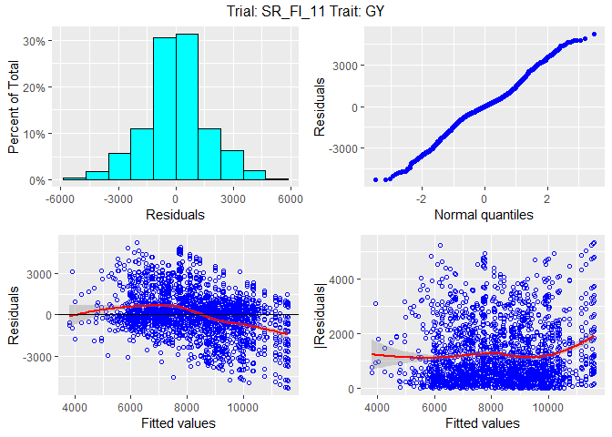

```r
## Plot for the model with genotype fitted as random effect.
plot(modWheatSp, what = "random")
```

The second type of plot consists of 5 plots, spatial plots of the raw data, fitted values, residuals and either BLUEs or BLUPs, and a histogram of the BLUEs or BLUPs. If SpATS was used as modeling engine an extra plot with the fitted spatial trend is included. The call for creating these plots differs from the base plots only by an extra parameter `plotType = "spatial"`.

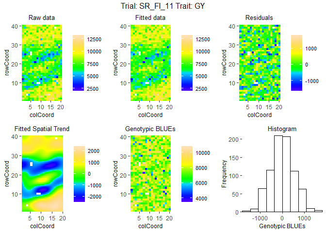

```r
## Spatial plot for the model with genotype fitted as fixed effect.
plot(modWheatSp, plotType = "spatial")
```

## 3.5 Model reports

As with many objects in the RAP package there is a `report` function available for `SSA` objects. This `report` function creates a pdf report describing the main results of the fitted model. Also the tex file is saved that was used for generating the pdf report. By editing the tex file it is possible to modify the report to ones needs creating high flexibility.

When no outfile is given a report will be created with a default name in the current working directory. The parameter `outfile` can be used to change this. This value of this parameter should be a valid location and name for a **pdf** file, i.e. including the postfix “.pdf”. Non-existing directories are be created by the `report` function.

```r
## Create a report in the current working directory
report(modWheatSp)
## Create a report for the model with genotype fitted as random.
report(modWheatSp, outfile = "./myReports/wheatReport.pdf", what = "random")
```

Similar to plotting an `SSA` object reporting is also done for 1 trait in 1 trial for 1 fitted model. Selection of the model to report is done in the same way as for plotting described in the previous section. Parameters `trait`, `trial` and `what` can be used for this.

# 4 Extracting model results

After fitting a model various results can be extracted or calculated from the fitted model using the function `STExtract`. This can be anything from a single result for 1 trait and 1 trial to a `list` of different results for all models in an `SSA` object. The results that can be extracted depend on the type of model fitted and sometimes on the modeling engine as well. For example, BLUEs can only extracted if genotype was fitted as fixed effect whereas BLUPs and heritabilities can only be extracted and calculated if genotype was fitted as random effect.

## 4.1 Possible results to extract

All results that can be extracted are shown in the table below. The first column shows what model needs to be fitted in order to be able to extract the result. F stands for genotype as fixed effect, R for genotype as random effect. In the second column is the result. This is also the value to be used for the parameter `what` in `STExtract` needed to extract the corresponding result. The last column gives a short description of the result that will be extracted and where needed also states for which modeling engines it can be extracted.

| model | result | description |
| --- | --- | --- |
| F | BLUEs | Best Lineair Unbiased Estimators |
| F | seBLUES | standard errors of the BLUEs |
| R | BLUPs | Best Lineair Unbiased Predictors |
| R | seBLUPs | standard errors of the BLUPs |
| F | ue | unit errors - only for `lme4` and `asreml` |
| R | heritability | broad sense heritability |
| F | varCompF | variance components for the model with genotype as fixed component |
| R | varCompR | variance components for the model with genotype as random component |
| R | varGen | genetic variance component |
| R | varErr | residual variance component - only for `lme4` and `asreml` |
| R | varSpat | spatial variance components - only for `SpATS` |
| F | fitted | fitted values for the model with genotype as fixed component |
| F | resid | residuals for the model with genotype as fixed component |
| F | stdRes | standardized residuals for the model with genotype as fixed component - only for `lme4` and `asreml` |
| R | rMeans | fitted values for the model with genotype as random component |
| R | ranEf | random genetic effects |
| F | wald | results of the wald test - only for `lme4` and `asreml` |
| F | CV | Coefficient of Variation - only for `lme4` and `asreml` |
| F | rDf | residual degrees of freedom |
| R | effDim | effective dimensions - only for `SpATS` |
| R | ratEffDim | ratios of the effective dimensions - only for `SpATS` |
| F | sed | standard error of difference - only for `asreml` |
| F | lsd | least significant difference - only for `asreml` |

Using `what = "all"` in the function call extracts all results possible for the fitted model. This is also the default.

Below are some examples of extracting results from a fitted model. Recall that `modWheatSp` contains 2 fitted models, 1 with genotype as fixed effect and 1 with genotype as random effect.

```r
## Extract BLUEs
BLUEsWheat <- STExtract(SSA = modWheatSp, what = "BLUEs")
## Extract BLUEs and BLUPs
predWheat <- STExtract(SSA = modWheatSp, what = c("BLUEs", "BLUPs"))
```

Both `BLUEsWheat` and `predWheat` are a `list` with 1 item, the trial used for modeling. In general there will be an item in the `list` for every trial for which results were extracted. These items are a `list` themselves with an item for every statistic that has been extracted, so 1 item for `BLUEsWheat`, a `data.frame` containing the BLUEs and 2 for `predWheat`, the `data.frames` containing BLUEs and BLUPs respectively.

## 4.2 Adding extra variables

The `data.frame` BLUEs in either of the `lists` consists of only 2 columns, genotype and GY. If the model would have been fitted for multiple traits all these traits would become columns in the `data.frame`. It might be useful to add extra columns from the data used to fit the model to the output. This can be achieved using the paramater `keep` in `STExtract`. To include the trial in the output, useful for easily combining several `data.frames` with BLUEs and using them for a GxE analysis use the following command

```r
BLUEsWheat2 <- STExtract(SSA = modWheatSp, what = "BLUEs", keep = "trial")
head(BLUEsWheat2[[1]]$BLUEs)
```

```
#>   genotype    trial       GY
#> 1     G001 SR_FI_11 8828.678
#> 2     G002 SR_FI_11 8592.090
#> 3     G003 SR_FI_11 8942.543
#> 4     G004 SR_FI_11 6804.189
#> 5     G005 SR_FI_11 8224.345
#> 6     G006 SR_FI_11 7443.286
```

Not every column from the original `TD` object can be included in the extracted data in this way. Only columns for which the values are uniform per genotype can be included. For example the column `repId` containing replicates that usually has several different values for a single genotype cannot be included. When trying to do so it will be dropped with a warning.  
It is however possible to include `repId` when extracting fitted values since for each observation in the original data a fitted value is returned.

```r
fitVals <- STExtract(SSA = modWheatSp, what = "fitted",
                     keep = c("trial", "repId"))
head(fitVals[[1]]$fitted)
```

```
#>   repId genotype    trial       GY
#> 1     1     G275 SR_FI_11 8234.353
#> 2     1     G325 SR_FI_11 7660.984
#> 3     1     G119 SR_FI_11 6675.174
#> 4     1     G138 SR_FI_11 7638.940
#> 5     1     G296 SR_FI_11 8409.450
#> 6     1     G257 SR_FI_11 5556.333
```

## 4.3 Prepare data for GxE analysis

To use the BLUEs or BLUPs from the fitted model in a GxE analysis they have to be converted again into an `TD` object. For the the function `SSAtoTD` can be used. It creates a `TD` object from a fitted model outputting one or more of the following: BLUEs, standard error of BLUEs, BLUPs, standard error of BLUPs. Optionally a column `wt` with weights (1 / standard error of BLUEs) can be added as well. In the same way as described in the previous section extra columns can be added to the output using the parameter `keep`.

```r
## Fit a model for all trials with genotype as fixed factor.
modWheatSpTot <- STRunModel(TD = wheatTD, traits = "GY", what = "fixed", design = "res.rowcol")
```

[output not shown]

```r
TDGxE <- SSAtoTD(SSA = modWheatSpTot, what = c("BLUEs", "seBLUEs"))
## Add weights to the output.
TDGxE2 <- SSAtoTD(SSA = modWheatSpTot, what = c("BLUEs", "seBLUEs"), addWt = TRUE)
summary(TDGxE2, trial = "SR_FI_11", traits =  c("BLUEs_GY", "seBLUEs_GY"))
```

```
#>
#> Summary statistics for BLUEs_GY in SR_FI_11
#>
#>     Number of observations  383
#>   Number of missing values  1
#>                       Mean  7783.02
#>                     Median  7775.77
#>                        Min  3676.51
#>                        Max  10649.75
#>             Lower quartile  7196.57
#>             Upper quartile  8429.06
#>                   Variance  1090904.682
#>
#> Summary statistics for seBLUEs_GY in SR_FI_11
#>
#>     Number of observations  383
#>   Number of missing values  1
#>                       Mean  670.88
#>                     Median  670.27
#>                        Min  344.14
#>                        Max  909.2
#>             Lower quartile  666.13
#>             Upper quartile  674.58
#>                   Variance  1057.807
```

See the vignette Genotype by Environment analysis using RAP for an overview of how to use the input just created for performing GxE analysis.

# References

Bates, Douglas, Martin Mächler, Ben Bolker, and Steve Walker. 2015. “Fitting Linear Mixed-Effects Models Using Lme4.” *Journal of Statistical Software* 67 (1). doi:10.18637/jss.v067.i01.

Gilmour, A.R., B.J. Gogel, B.R. Cullis, and R. Thompson. 2009. “ASReml User Guide Release 3.0.” VSN International Ltd, Hemel Hempstead, HP1 1ES, UK. https://www.vsni.co.uk/.

Lado, Bettina, Ivan Matus, Alejandra Rodríguez, Luis Inostroza, Jesse Poland, François Belzile, Alejandro del Pozo, Martín Quincke, Marina Castro, and Jarislav von Zitzewitz. 2013. “Increased Genomic Prediction Accuracy in Wheat Breeding Through Spatial Adjustment of Field Trial Data.” *G3: Genes$\vert$Genomes$\vert$Genetics* 3 (12): 2105–14. doi:10.1534/g3.113.007807.

Lee, Dae-Jin, María Durbán, and Paul Eilers. 2013. “Efficient Two-Dimensional Smoothing with P-Spline Anova Mixed Models and Nested Bases.” *Computational Statistics & Data Analysis* 61 (May): 22–37. doi:10.1016/j.csda.2012.11.013.

Rodríguez-Álvarez, María, Martin P. Boer, Fred Eeuwijk, and Paul H.C. Eilers. 2017. “Correcting for Spatial Heterogeneity in Plant Breeding Experiments with P-Splines.” *Spatial Statistics* 23 (October): 52–71. doi:10.1016/j.spasta.2017.10.003.